# Radar-Chart

Jarno Jacob Duiker & Storm Steller

2024-05-30

# Radar Chart

```r
library(fmsb)
library(ggplot2)
library(dplyr)
#Lees de data in
research_data <- read.csv("Studenthap_ant.csv")

#Verander de namen van de kolommen
colnames(research_data) <- c("Tijdstempel", "Sexe", "Niveau", "Jaar", "Vakgebied", "Woonsituatie", "Stad", "Nationaal/Internationaal", "Gelovig", "Relatie", "Algemeen_Geluk", "Fysiek_Geluk", "Belang_Fysieke_Gezondheid", "Belang_Buitenschools_Contact", "Belang_Sociale_Activiteiten", "Band_Ouders", "Geluk_Woonsituatie", "Thuisgevoel", "Belang_Academische_Prestaties", "Financiele_Situatie", "Belang_Geld", "Gebruik_Verdovende_Middelen", "Belang_Verdovende_Middelen", "Lekker_In_Vel", "Geluk_Na_Enquête")
```

```r
head(research_data)
```

```
##          Tijdstempel           Sexe Niveau     Jaar             Vakgebied
## 1 29-4-2024 23:31:08 Vrouw (Female)    HBO 1e (1st)          Lifesciences
## 2 30-4-2024 10:21:58     Man (Male)    HBO 1e (1st)          Lifesciences
## 3  1-5-2024 13:50:47 Vrouw (Female)    HBO 1e (1st)          Lifesciences
## 4  1-5-2024 18:00:36 Vrouw (Female)    HBO 1e (1st) Technisch (Technical)
## 5  2-5-2024 18:29:14     Man (Male)    HBO 1e (1st) Technisch (Technical)
## 6 14-5-2024 15:50:23 Vrouw (Female)    MBO 1e (1st)        Anders (Other)
##            Woonsituatie      Stad Nationaal/Internationaal  Gelovig  Relatie
## 1 Thuiswonend (At home) Groningen     Nationaal (National) Nee (No) Nee (No)
## 2 Thuiswonend (At home) Groningen     Nationaal (National) Nee (No) Nee (No)
## 3 Thuiswonend (At home) Groningen     Nationaal (National) Ja (Yes) Ja (Yes)
## 4 Thuiswonend (At home) Groningen     Nationaal (National) Nee (No) Nee (No)
## 5 Thuiswonend (At home) Groningen     Nationaal (National) Nee (No) Nee (No)
## 6 Thuiswonend (At home) Groningen     Nationaal (National) Ja (Yes) Nee (No)
##   Algemeen_Geluk Fysiek_Geluk Belang_Fysieke_Gezondheid
```

[output cut: 34 more lines]

```r
#Haal de kolommen die in de chart moeten uit de dataframe
display_data <- select(research_data, c(Fysiek_Geluk,
                                        Belang_Buitenschools_Contact,
                                        Geluk_Woonsituatie,
                                        Thuisgevoel,
                                        Belang_Academische_Prestaties,
                                        Belang_Geld,
                                        Lekker_In_Vel))

head(display_data)
```

```
##   Fysiek_Geluk Belang_Buitenschools_Contact Geluk_Woonsituatie Thuisgevoel
## 1            7                            8                  4           7
## 2            9                            7                  7           7
## 3            7                            6                  6           4
## 4            8                            7                  9           7
## 5            3                            8                  5           8
## 6            3                           10                  6          10
##   Belang_Academische_Prestaties Belang_Geld Lekker_In_Vel
## 1                             9           9             4
## 2                            10           8             5
## 3                             3           6             5
## 4                             6           7             8
## 5                             8           6             4
## 6                             7           7             8
```

```r
#Zet een maximum- en minimum waarde in voor de grafiek
max_min <- data.frame(Fysiek_Geluk = c(10,0),
                       Belang_Buitenschools_Contact = c(10,0),
                       Geluk_Woonsituatie = c(10,0),
                       Thuisgevoel = c(10,0),
                       Belang_Academische_Prestaties = c(10,0),
                       Belang_Geld = c(10,0),
                       Lekker_In_Vel = c(10,0)
                      )

row.names(max_min) <- c("Max", "Min")

#Bind de max en min aan data en zet het in een dataframe
df <- rbind(max_min, display_data)
head(df)
```

```
##     Fysiek_Geluk Belang_Buitenschools_Contact Geluk_Woonsituatie Thuisgevoel
## Max           10                           10                 10          10
## Min            0                            0                  0           0
## 1              7                            8                  4           7
## 2              9                            7                  7           7
## 3              7                            6                  6           4
## 4              8                            7                  9           7
##     Belang_Academische_Prestaties Belang_Geld Lekker_In_Vel
## Max                            10          10            10
## Min                             0           0             0
## 1                               9           9             4
## 2                              10           8             5
## 3                               3           6             5
## 4                               6           7             8
```

## Visualisatie

### Radar Chart Met Alle Studenten

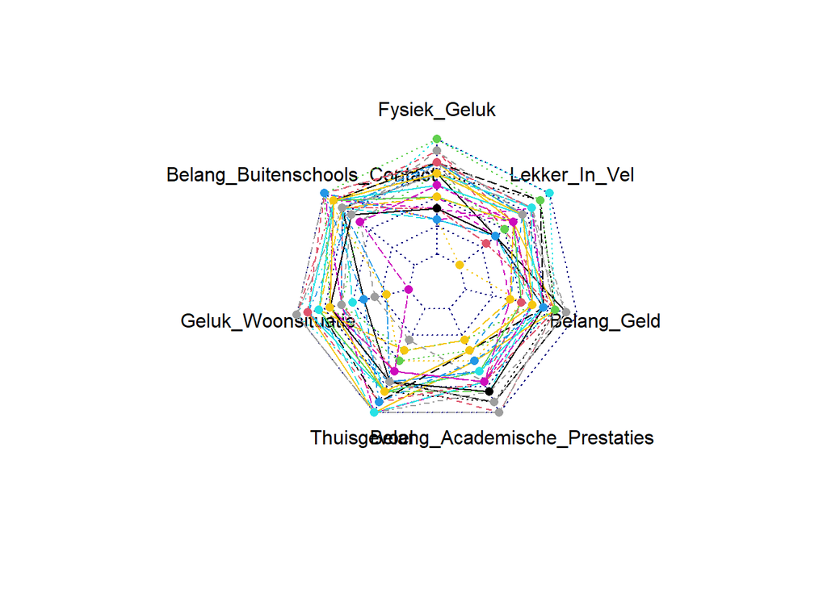

```r
radarchart(df)
```

Dit een radar chart met alle studenten uit het dataframe. Het valt op dat de chart heel vol is, waardoor die niet goed te lezen is.

### Radar Chart Met 1 Student

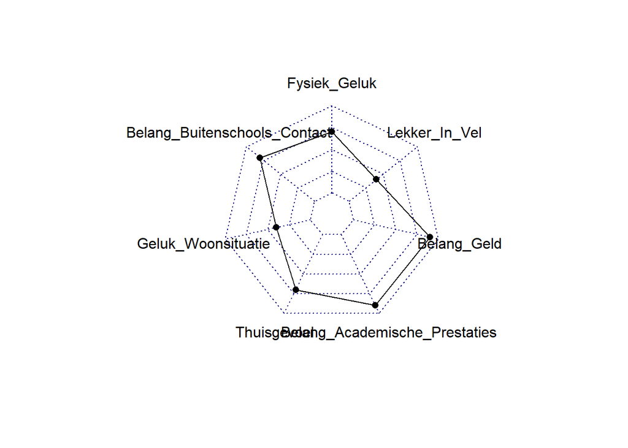

```r
#Selecteer de data van 1 individu
student_1 <- df[c("Max", "Min", "1"), ]

radarchart(student_1)
```

Dit is een Radarchart met de gegevens van 1 student. Dit ziet er al veel rustiger uit, maar dit kan beter opgemaakt.

```r
#Deze functie maakt een mooie radar chart, als parameters neemt de functie data, een kleur en een titel
js_radarchart <- function(data,
                             color,
                             vlabels = colnames(data),
                             title) {
    radarchart(
        data, axistype = 1,

        #Hier worden de kleuren en de lijntypes van de grafiekdata opgezet
        pcol = color,
        pfcol = scales::alpha(color, 0.5),
        plwd = 1,
        plty = 1,

        #Hier is de opmaak van het rooster van de grafiek
        cglcol = "grey",
        cglty = 1,
        cglwd = .8,
        caxislabels = NULL,
        calcex = .75,

        #Hier wordt de kleur en grootte van de as labels bepaald
        axislabcol = "black",
        vlcex = .80,
        vlabels = vlabels,
        title = title,
    )
}
```

Hierboven hebben we een functie gemaakt die een radar chart plot die wel mooi is.

### Mooie Radar Chart met 1 student

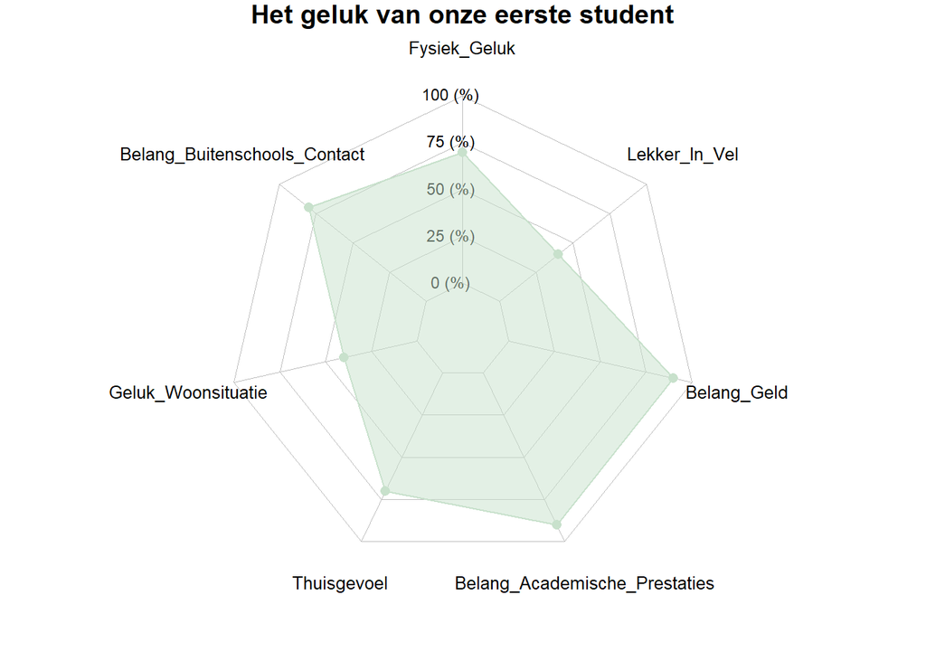

```r
#Zet grafische parameters voor de grafieken
op <- par(mar = c(1, 1, 1, 1))

js_radarchart(data= student_1, color= "#c8e1cc", title= "Het geluk van onze eerste student")
```

```r
par(op)
```

Dit ziet er al een stuk beter uit. Nu zit er een titel in de grafiek, zit er een kleur vast aan het individu voor de duidelijkheid, en staat er in welke eenheid de grafiek is.

### 5 Studenten Naast Elkaar

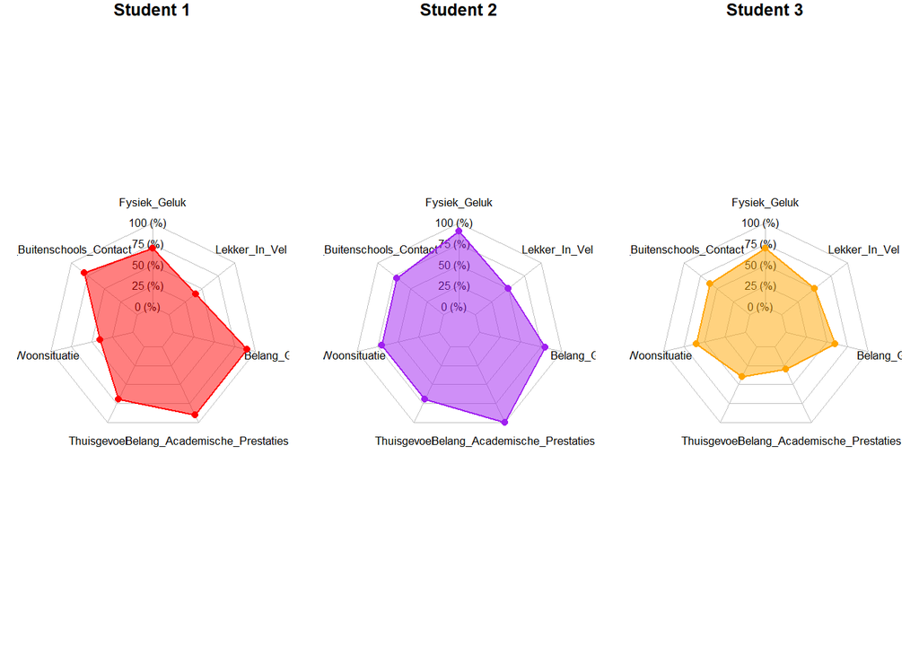

```r
#Zet de kleuren voor de idividuen
colors <- c("red", "purple", "orange", "yellow", "blue")

#Zet de titels voor de individuen
titles <- c("Student 1", "Student 2", "Student 3", "Student 4", "Student 5")


op <- par(mar = c(1, 1, 1, 1))
par(mfrow = c(1,3))

#Met een for loop maken we voor elk individu een aparte grafiek
for(i in 1:5){
  js_radarchart(
    data = df[c(1, 2, i+2), ],
    color = colors[i],
    title = titles[i]
    )
}
```

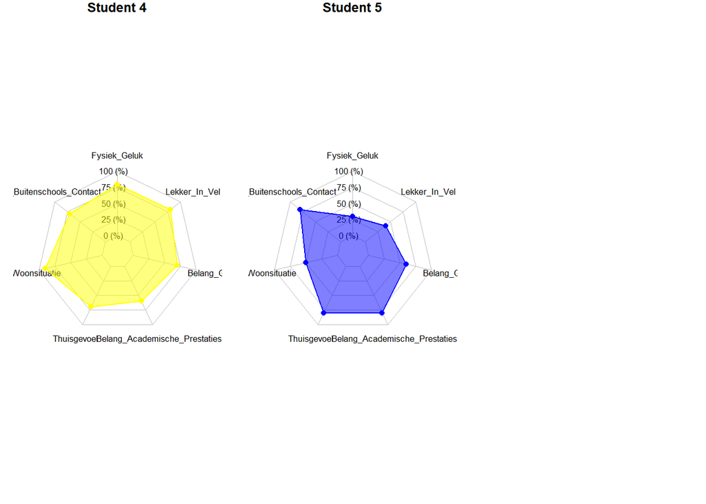

```r
par(op)
```

Hier zie je 5 grafieken. In elk staat het geluk van een student die onze enquête heeft ingevuld. Hiermee kan je ongeveer de verschillen tussen van het geluk tussen de individuen zien, maar het is wat duidelijker als je de individuen overlapt in een enkele grafiek.

### Maken Belangrijke Functie

```r
#Een functie die het gemiddelde van data in een dataframe berekent en er een nieuwe dataframe van maakt
mean_frame <- function(data){
  as.data.frame(t(colMeans(data)))
}

#Een functie die data afrond
round_data <- function(data, digits) {
  nums <- vapply(data, is.numeric, FUN.VALUE = logical(1))

  data[,nums] <- round(data[,nums], digits = digits)

  (data)
}

#Maak een dataframe met de gemiddelden van alle variabelen
df_mean <- mean_frame(display_data)

#Rond het gemiddelde af tot getallen met 1 decimaal
df_mean <- round_data(df_mean, 1)

#Geef de data een maximale- en minimale grens voor in de grafiek
df_mean <- rbind(max_min, df_mean)

df_mean
```

```
##     Fysiek_Geluk Belang_Buitenschools_Contact Geluk_Woonsituatie Thuisgevoel
## Max         10.0                         10.0               10.0        10.0
## Min          0.0                          0.0                0.0         0.0
## 1            6.6                          8.4                6.7         7.4
##     Belang_Academische_Prestaties Belang_Geld Lekker_In_Vel
## Max                          10.0        10.0          10.0
## Min                           0.0         0.0           0.0
## 1                             6.5         6.5           6.2
```

Hierboven hebben we een functie gemaakt die de gemiddelden van alle variabelen uitrekent en ze in een nieuw dataframe zet. Daarna hebben we ook een functie gemaakt die de data afrond, omdat zoveel decimalen onnodig zijn.

### Grafiek Met Gemiddeld Geluk

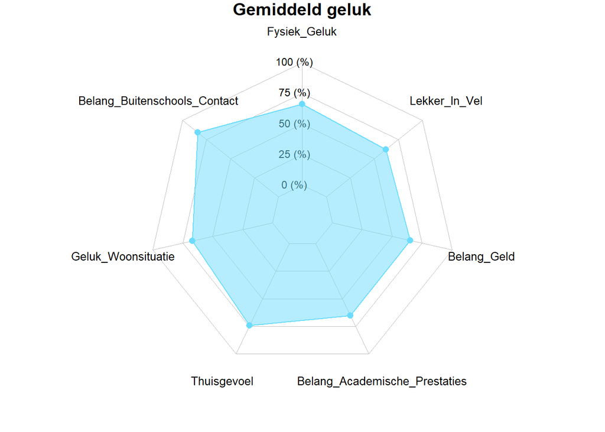

```r
op <- par(mar = c(1, 1, 1, 1))

#Maak een grafiek van het gemiddeld geluk van alle individuen uit de dataset
js_radarchart(data= df_mean, color= "#6bdcff", title= "Gemiddeld geluk")
```

```r
par(op)
```

Hierboven zie je een grafiek met het gemiddeld geluk van alle individuen uit de dataset. Dit is wel mooi, maar nu willen we vergelijken. Nu gaan wij de data opsplitsen zodat we ze met elkaar kunnen vergelijken.

### Grafiek Gesplitst Op Sexe

```r
#Voege de sexe kolom terug aan de dataframe
display_data$Sexe <- research_data$Sexe

#Verander de namen van de waarden om het later makkelijker te maken
display_data$Sexe[display_data$Sexe == 'Vrouw (Female)'] <- "Vrouw"
display_data$Sexe[display_data$Sexe == 'Man (Male)'] <- "Man"
display_data$Sexe[display_data$Sexe == 'Anders (Other)'] <- "Anders"

head(display_data)
```

```
##   Fysiek_Geluk Belang_Buitenschools_Contact Geluk_Woonsituatie Thuisgevoel
## 1            7                            8                  4           7
## 2            9                            7                  7           7
## 3            7                            6                  6           4
## 4            8                            7                  9           7
## 5            3                            8                  5           8
## 6            3                           10                  6          10
##   Belang_Academische_Prestaties Belang_Geld Lekker_In_Vel  Sexe
## 1                             9           9             4 Vrouw
## 2                            10           8             5   Man
## 3                             3           6             5 Vrouw
## 4                             6           7             8 Vrouw
## 5                             8           6             4   Man
## 6                             7           7             8 Vrouw
```

```r
#Reken de gemiddelden van de individuen gesplitst op sexe
mean_man <- mean_frame(display_data[display_data$Sexe == 'Man', 1:7])
mean_vrouw <- mean_frame(display_data[display_data$Sexe == 'Vrouw', 1:7])
mean_anders <- mean_frame(display_data[display_data$Sexe == 'Anders', 1:7])

#Zet alle gemiddelden in een dataframe met de maximale- en minimale grens
df_mean_sexe <- rbind(max_min, mean_man, mean_vrouw, mean_anders)

#Zet de correcte titels voor de rijen in de dataframe
rownames(df_mean_sexe) <- c("Max", "Min", "Man", "Vrouw", "Anders")

#Rond de waarden in de dataframe af
df_mean_sexe <- round_data(df_mean_sexe, 1)

df_mean_sexe
```

```
##        Fysiek_Geluk Belang_Buitenschools_Contact Geluk_Woonsituatie Thuisgevoel
## Max            10.0                         10.0               10.0        10.0
## Min             0.0                          0.0                0.0         0.0
## Man             6.8                          8.1                6.8         7.8
## Vrouw           6.8                          8.5                6.8         7.5
## Anders          4.0                          9.0                5.0         4.5
##        Belang_Academische_Prestaties Belang_Geld Lekker_In_Vel
## Max                             10.0        10.0          10.0
## Min                              0.0         0.0           0.0
## Man                              7.1         7.1           6.5
## Vrouw                            6.4         6.4           6.5
## Anders                           4.0         4.5           3.0
```

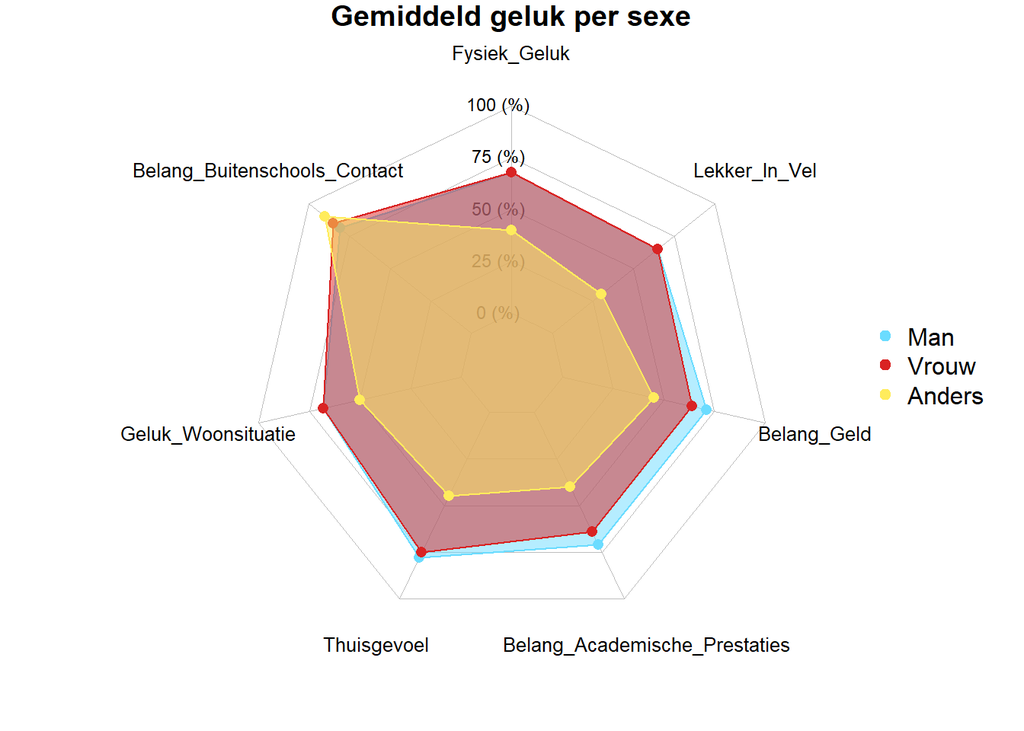

```r
op <- par(mar = c(1, 1, 1, 1))

#Zet de kleuren voor de individuen in de grafiek
colors <- c("#6bdcff", "#d92323", "#ffec5c")

js_radarchart(data= df_mean_sexe, color= colors, title= "Gemiddeld geluk per sexe")

#Maak een legenda voor de grafiek
legend(
  x = "right",
  legend = c("Man", "Vrouw", "Anders"),
  horiz = FALSE,
  bty = "n",
  pch = 20 ,
  col = colors,
  text.col = "black",
  cex = 1,
  pt.cex = 1.5
  )
```

```r
par(op)
```

Hierboven zie je een grafiek van het gemiddeld geluk van de individuen uit de dataset gesplitst op sexe. Dit is mooi. Hier kan je goed de verschillen zien tussen de 3 sexes. Wat opvalt is dat de categorie anders gemiddeld op bijna alles lager scoort dan de rest.

### Voorbeeld Van Een Uitschieter

```r
#Manipuleer de data zodat er uitschieters zijn
df_mean_sexe["Belang_Academische_Prestaties"][df_mean_sexe["Belang_Academische_Prestaties"] == 7.1] <- 10
df_mean_sexe["Belang_Buitenschools_Contact"][df_mean_sexe["Belang_Buitenschools_Contact"] == 9.0] <- 0

df_mean_sexe
```

```
##        Fysiek_Geluk Belang_Buitenschools_Contact Geluk_Woonsituatie Thuisgevoel
## Max            10.0                         10.0               10.0        10.0
## Min             0.0                          0.0                0.0         0.0
## Man             6.8                          8.1                6.8         7.8
## Vrouw           6.8                          8.5                6.8         7.5
## Anders          4.0                          0.0                5.0         4.5
##        Belang_Academische_Prestaties Belang_Geld Lekker_In_Vel
## Max                             10.0        10.0          10.0
## Min                              0.0         0.0           0.0
## Man                             10.0         7.1           6.5
## Vrouw                            6.4         6.4           6.5
## Anders                           4.0         4.5           3.0
```

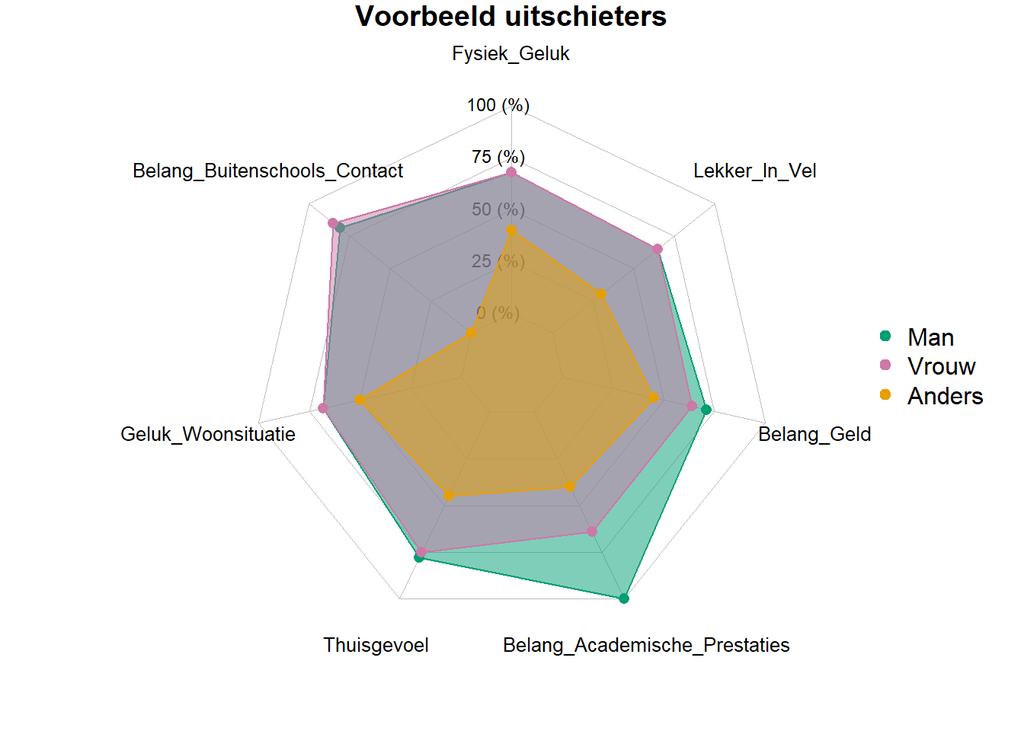

```r
op <- par(mar = c(1, 1, 1, 1))

#Zet de kleuren voor de individuen in de grafiek
colors <- c("#009E73", "#CC79A7", "#E69F00")

js_radarchart(data= df_mean_sexe, color= colors, title= "Voorbeeld uitschieters")

#Maak een legenda voor de grafiek
legend(
  x = "right",
  legend = c("Man", "Vrouw", "Anders"),
  horiz = FALSE,
  bty = "n",
  pch = 20 ,
  col = colors,
  text.col = "black",
  cex = 1,
  pt.cex = 1.5
  )
```

```r
par(op)
```

Hierboven zie je een grafiek met een voorbeeld van 2 uitschieters. De mannen vinden gemiddeld hun academische prestaties veel belangrijker dan de rest en de categorie anders vindt gemiddeld buitenschools contact veel minder belangrijk dan de rest. (Dit is niet de daadwerkelijke data uit de dataset. Deze data is gemanipuleerd om uitschieters te creeëren)

### Grafiek Met Verschillende Schaal In Waarden

```r
#Zet een maximum- en minimum waarde in voor de grafiek
max_min5 <- data.frame(Fysiek_Geluk = c(10,0),
                       Belang_Buitenschools_Contact = c(5,0),
                       Geluk_Woonsituatie = c(10,0),
                       Thuisgevoel = c(5,0),
                       Belang_Academische_Prestaties = c(10,0),
                       Belang_Geld = c(5,0),
                       Lekker_In_Vel = c(10,0)
                      )
row.names(max_min5) <- c("Max", "Min")

#Haal de oude maximum- en minimumgrens weg
df_mean <- df_mean[, 3]

#Bind de nieuwe maximum- en minimumgrens aan de dataframe
df_disproportioneel <- rbind(max_min5, df_mean)
df_disproportioneel
```

```
##     Fysiek_Geluk Belang_Buitenschools_Contact Geluk_Woonsituatie Thuisgevoel
## Max           10                            5               10.0           5
## Min            0                            0                0.0           0
## 3             10                            0                6.7          10
##     Belang_Academische_Prestaties Belang_Geld Lekker_In_Vel
## Max                            10         5.0            10
## Min                             0         0.0             0
## 3                               0         6.7            10
```

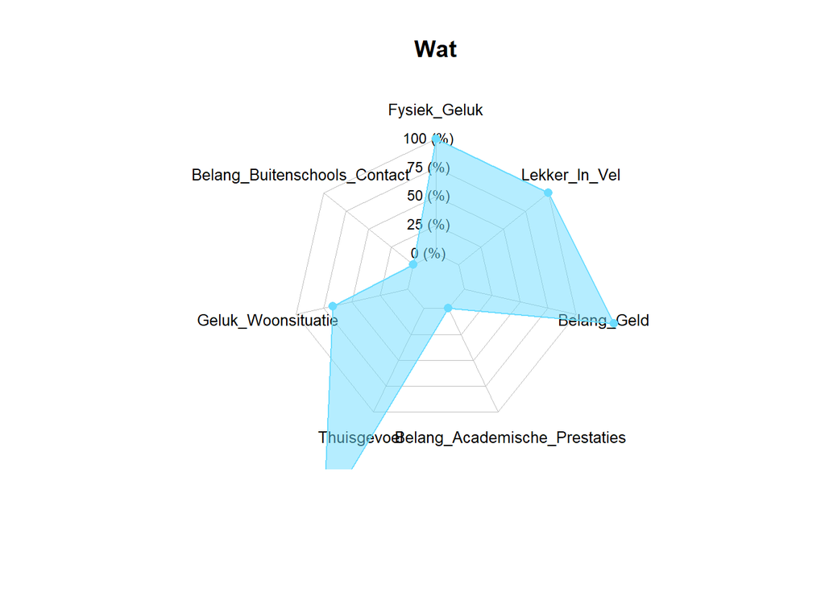

```r
js_radarchart(data= df_disproportioneel, color="#6bdcff", title= "Wat")
```

Hierboven zie je een poging tot een grafiek te plotten met verschillende schalen in waarden. Zoals je ziet schiet de waarde voorbij de as, wat niet de bedoeling is. Er ook is geen optie in de functie om ervoor te zorgen dat de waarde niet voorbij de as schiet. Waarschijnlijk gebeurt dit omdat dit ook wel eens gebruikt wordt om extreme uitschieters te laten zien.